# Planning Unit Reconciliation: Build - Module Report

## 1 Summary

This analysis performed Planning Unit Reconciliation (PUR) on the Bungo landscape. The total area analyzed was 461,658 hectares. Of this, 80.58% (372,002 ha) was successfully reconciled, while 19.42% (89,656 ha) remained unresolved and requires further reconciliation action.

## 2 Module brief description

Planning unit reconciliation is a process to resolve overlapping permits by referring to function reference maps. Reconciliation is done by analyzing how well the permit data matches the reference data. Permit data can include things like forest management concessions, plantation permits, mining permits, and others. Reference data can be spatial planning data or area designation data.

## 3 Input data

### 3.1 Reference Map

This data is used as a guide to check if the maps of planning areas match their intended use. These maps can be official maps showing land use or city planning.

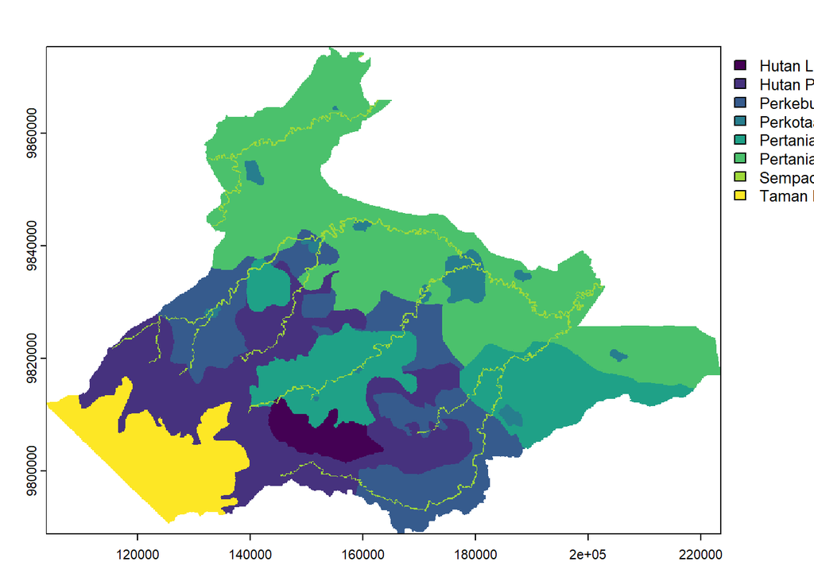

### 3.2 Planning Unit Map

Planning unit data is used to show how land use is planned in an area. These map-based data show directions for managing or changing land use in a part of the landscape.

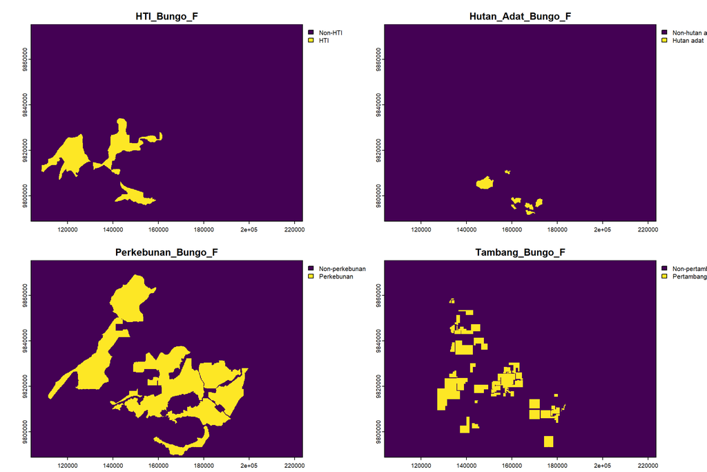

## 4 Results

### 4.1 Unresolved Cases Zone Map

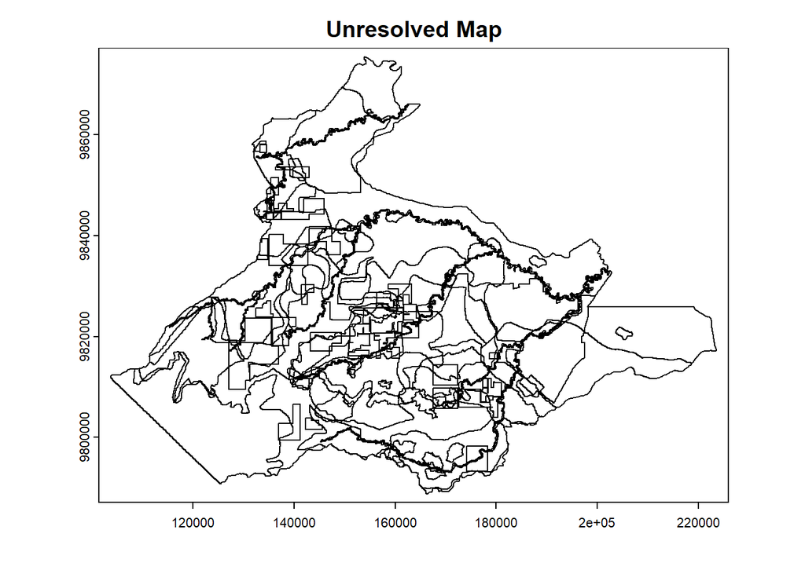

### 4.2 Summary of Unresolved Cases

Summary of Reconciliation Results

| Rec_phase1b | Area_ha | Percentage |
| --- | --- | --- |
| Pertanian Lahan Kering | 146695 | 31.775687 |
| unresolved_case | 89656 | 19.420437 |
| Pertanian Lahan Basah | 58108 | 12.586807 |
| Perkebunan | 56568 | 12.253226 |
| Hutan Produksi | 43275 | 9.373822 |
| Taman Nasional Kerinci Sebelat | 41941 | 9.084864 |
| Perkotaaan | 10131 | 2.194482 |
| Sempadan Sungai | 8102 | 1.754979 |
| Hutan Lindung | 7182 | 1.555697 |